# Project: Medical Appointment No Shows

- Introduction
- Data Wrangling
- Exploratory Data Analysis
- Conclusions

## Introduction

> The collection of data here is about patients not showing up to there medical appointments in Brazil and few questions are going to be answered by investigating this dataset features and finding relationships between them and how are they affected by each other.

## Questions To Be Answered

- Whether people with certain chronic disease tend to experience higher rate no show appointments?
- Which age range tend to miss their appointments?
- Is contacting patient through SMS help in raising the possibility of showing compare to those who did not receive one?

```python
import numpy as np
import pandas as pd
import matplotlib.pyplot as plt
import seaborn as sns
%matplotlib inline
```

## Data Wrangling

### General Properties

```python
noshow=pd.read_csv('KaggleV2-May-2016.csv')
```

```python
noshow.head()
```

|  | PatientId | AppointmentID | Gender | ScheduledDay | AppointmentDay | Age | Neighbourhood | Scholarship | Hipertension | Diabetes | Alcoholism | Handcap | SMS_received | No-show |
| --- | --- | --- | --- | --- | --- | --- | --- | --- | --- | --- | --- | --- | --- | --- |
| 0 | 2.987250e+13 | 5642903 | F | 2016-04-29T18:38:08Z | 2016-04-29T00:00:00Z | 62 | JARDIM DA PENHA | 0 | 1 | 0 | 0 | 0 | 0 | No |
| 1 | 5.589978e+14 | 5642503 | M | 2016-04-29T16:08:27Z | 2016-04-29T00:00:00Z | 56 | JARDIM DA PENHA | 0 | 0 | 0 | 0 | 0 | 0 | No |
| 2 | 4.262962e+12 | 5642549 | F | 2016-04-29T16:19:04Z | 2016-04-29T00:00:00Z | 62 | MATA DA PRAIA | 0 | 0 | 0 | 0 | 0 | 0 | No |
| 3 | 8.679512e+11 | 5642828 | F | 2016-04-29T17:29:31Z | 2016-04-29T00:00:00Z | 8 | PONTAL DE CAMBURI | 0 | 0 | 0 | 0 | 0 | 0 | No |
| 4 | 8.841186e+12 | 5642494 | F | 2016-04-29T16:07:23Z | 2016-04-29T00:00:00Z | 56 | JARDIM DA PENHA | 0 | 1 | 1 | 0 | 0 | 0 | No |

```python
noshow.info()
```

```
<class 'pandas.core.frame.DataFrame'>
RangeIndex: 110527 entries, 0 to 110526
Data columns (total 14 columns):
 #   Column          Non-Null Count   Dtype
---  ------          --------------   -----
 0   PatientId       110527 non-null  float64
 1   AppointmentID   110527 non-null  int64
 2   Gender          110527 non-null  object
 3   ScheduledDay    110527 non-null  object
 4   AppointmentDay  110527 non-null  object
 5   Age             110527 non-null  int64
 6   Neighbourhood   110527 non-null  object
 7   Scholarship     110527 non-null  int64
 8   Hipertension    110527 non-null  int64
 9   Diabetes        110527 non-null  int64
 10  Alcoholism      110527 non-null  int64
 11  Handcap         110527 non-null  int64
 12  SMS_received    110527 non-null  int64
 13  No-show         110527 non-null  object
dtypes: float64(1), int64(8), object(5)
memory usage: 9.7+ MB
```

```python
noshow.nunique()
```

[output not shown]

```python
noshow.describe()
```

|  | PatientId | AppointmentID | Age | Scholarship | Hipertension | Diabetes | Alcoholism | Handcap | SMS_received |
| --- | --- | --- | --- | --- | --- | --- | --- | --- | --- |
| count | 1.105270e+05 | 1.105270e+05 | 110527.000000 | 110527.000000 | 110527.000000 | 110527.000000 | 110527.000000 | 110527.000000 | 110527.000000 |
| mean | 1.474963e+14 | 5.675305e+06 | 37.088874 | 0.098266 | 0.197246 | 0.071865 | 0.030400 | 0.022248 | 0.321026 |
| std | 2.560949e+14 | 7.129575e+04 | 23.110205 | 0.297675 | 0.397921 | 0.258265 | 0.171686 | 0.161543 | 0.466873 |
| min | 3.921784e+04 | 5.030230e+06 | -1.000000 | 0.000000 | 0.000000 | 0.000000 | 0.000000 | 0.000000 | 0.000000 |
| 25% | 4.172614e+12 | 5.640286e+06 | 18.000000 | 0.000000 | 0.000000 | 0.000000 | 0.000000 | 0.000000 | 0.000000 |
| 50% | 3.173184e+13 | 5.680573e+06 | 37.000000 | 0.000000 | 0.000000 | 0.000000 | 0.000000 | 0.000000 | 0.000000 |
| 75% | 9.439172e+13 | 5.725524e+06 | 55.000000 | 0.000000 | 0.000000 | 0.000000 | 0.000000 | 0.000000 | 1.000000 |
| max | 9.999816e+14 | 5.790484e+06 | 115.000000 | 1.000000 | 1.000000 | 1.000000 | 1.000000 | 4.000000 | 1.000000 |

In the above cells I read the data set using the **read()** function from pandas.Then I tried to go through the data to understand the nature of it, how many columns and tuples are there and other information regarding counts, means and few percentages using **info()** and **describe()** functions.

```python
noshow.duplicated()
```

```
0         False
1         False
2         False
3         False
4         False
          ...
110522    False
110523    False
110524    False
110525    False
110526    False
Length: 110527, dtype: bool
```

```python
noshow.drop(['PatientId','AppointmentID'],axis=1,inplace=True)
```

```python
noshow=noshow.rename(columns = {'No-show': 'NoShow'}, inplace = False)
```

```python
noshow.head()
```

|  | Gender | ScheduledDay | AppointmentDay | Age | Neighbourhood | Scholarship | Hipertension | Diabetes | Alcoholism | Handcap | SMS_received | NoShow |
| --- | --- | --- | --- | --- | --- | --- | --- | --- | --- | --- | --- | --- |
| 0 | F | 2016-04-29T18:38:08Z | 2016-04-29T00:00:00Z | 62 | JARDIM DA PENHA | 0 | 1 | 0 | 0 | 0 | 0 | No |
| 1 | M | 2016-04-29T16:08:27Z | 2016-04-29T00:00:00Z | 56 | JARDIM DA PENHA | 0 | 0 | 0 | 0 | 0 | 0 | No |
| 2 | F | 2016-04-29T16:19:04Z | 2016-04-29T00:00:00Z | 62 | MATA DA PRAIA | 0 | 0 | 0 | 0 | 0 | 0 | No |
| 3 | F | 2016-04-29T17:29:31Z | 2016-04-29T00:00:00Z | 8 | PONTAL DE CAMBURI | 0 | 0 | 0 | 0 | 0 | 0 | No |
| 4 | F | 2016-04-29T16:07:23Z | 2016-04-29T00:00:00Z | 56 | JARDIM DA PENHA | 0 | 1 | 1 | 0 | 0 | 0 | No |

The dataset is pretty clean as there is no missing data according to the **info()** results, in addition no duplicated values there as the **duplicated()** function output shows there is non. I chose to drop the **PatientId** and **AppointmentID** as they are irrelevant to the results I need in order to answer the proposed questions and to make it easier for me to navigate through the outputs, also I renamed the column **No-Show** to **NoShow** to remove the hyphen to overcome futer code manipulation problems.

## Exploratory Data Analysis

### Research Question 1 (Whether people with certain chronic disease tend to experience higher rate no show appointments?)

```python
show=noshow.NoShow =='Yes'
miss=noshow.NoShow =='No'
```

```python
def Myhist(x,noshow):
     if x =='Hipertension':
        noshow.Hipertension[show].hist(alpha=0.5, label='show')
        noshow.Hipertension[miss].hist(alpha=0.5, label='miss')
        plt.legend();

     else:
         if x=='Diabetes':
            noshow.Diabetes[show].hist(alpha=0.5, label='show')
            noshow.Diabetes[miss].hist(alpha=0.5, label='miss')
            plt.legend();
         else:
             if x=='Alcoholism':
                    noshow.Alcoholism[show].hist(alpha=0.5, label='show')
                    noshow.Alcoholism[miss].hist(alpha=0.5, label='miss')
                    plt.legend();
             else:
                 if x=='Handcap':
                    noshow.Handcap[show].hist(alpha=0.5, label='show')
                    noshow.Diabetes[miss].hist(alpha=0.5, label='miss')
                    plt.legend();
                 else:
                     if x=='Age':
                        noshow.Age[show].hist(alpha=0.5, label='show')
                        noshow.Age[miss].hist(alpha=0.5, label='miss')
                        plt.legend();
```

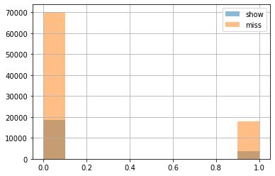

```python
Myhist('Hipertension',noshow)
```

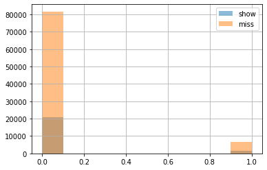

```python
Myhist('Diabetes',noshow)
```

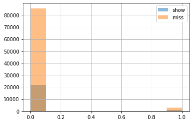

```python
Myhist('Alcoholism',noshow)
```

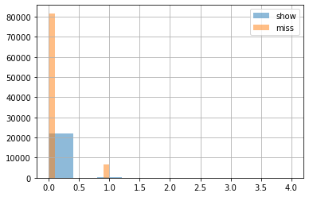

```python
Myhist('Handcap',noshow)
```

### Research Question 2 (Which Age Range Tend To Miss Their Appointments?)

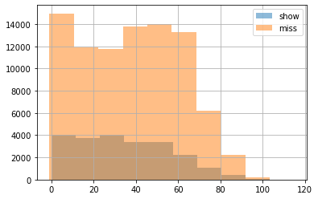

```python
Myhist('Age',noshow)
```

The above histograms show the relationship between the patients Age and whether it has an impact on them missing or showing to the appointment. It seems like the younger the patient the most likley they will miss the appointment.

### Research Question 3 (s contacting patient through SMS help in raising the possibility of showing compare to those who did not receive one?)

```python
SMS=noshow.groupby('NoShow').SMS_received.mean()
SMS
```

```
NoShow
No     0.291334
Yes    0.438371
Name: SMS_received, dtype: float64
```

In the above cell, I grouped the data in perspective to Noshow column and calculated the mean of those who Received SMS to get a close understanding of the relation between the two features (Received_SMS and Noshow)

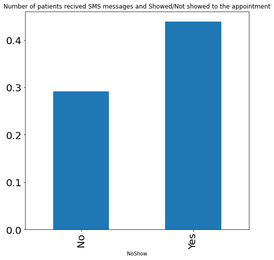

```python
SMS.plot(kind='bar',x='SMS Recived',y='Number of patients',figsize = (8,8),title='Number of patients recived SMS messages and Showed/Not showed to the appointment',fontsize=20);
```